# Literate Programming with R and BigQuery

## R Markdown Introduction

See the [`rmarkdown` package](http://cran.r-project.org/web/packages/rmarkdown/index.html) for more detail about how to use RMarkdown from R. [RStudio](http://www.rstudio.com/) has support for [R Markdown](http://rmarkdown.rstudio.com/) from its user interface.

## BigQuery Analysis of Variants

Now let us move onto [literate programming](http://en.wikipedia.org/wiki/Literate_programming) for [BigQuery](https://developers.google.com/bigquery/).

If you have not used the bigrquery package previously, you will likely need to do something like the following to get it installed:

```r
### Only needed the first time around
install.packages("devtools")
devtools::install_github("assertthat")
devtools::install_github("bigrquery")
```

Next we will load our needed packages into our session:

```r
library(bigrquery)
library(ggplot2)
library(xtable)
```

And write a little convenience function:

```r
project <- "google.com:biggene"                           # put your projectID here
table <- "genomics-public-data:platinum_genomes.variants" # put your table here
DisplayAndDispatchQuery <- function(queryUri) {
  # Read in the SQL from a file or URL.
  querySql <- readChar(queryUri, nchars=1e6)
  # Find and replace the table name placeholder with our table name.
  querySql <- sub("_THE_TABLE_", table, querySql, fixed=TRUE)
  # Display the updated SQL.
  cat(querySql)
  # Dispatch the query to BigQuery for execution.
  query_exec(querySql, project)
}
```

Now we’re ready to execute our query, bringing the results down to our R session for further examination:

```r
result <- DisplayAndDispatchQuery("../sql/sample-variant-counts-for-brca1.sql")
```

```
# Sample variant counts within BRCA1.
SELECT
  call_set_name,
  COUNT(call_set_name) AS variant_count,
FROM (
  SELECT
    reference_name,
    start,
    END,
    reference_bases,
    GROUP_CONCAT(alternate_bases) WITHIN RECORD AS alternate_bases,
    call.call_set_name AS call_set_name,
    NTH(1,
      call.genotype) WITHIN call AS first_allele,
    NTH(2,
      call.genotype) WITHIN call AS second_allele,
  FROM
      [genomics-public-data:platinum_genomes.variants]
  WHERE
    reference_name = 'chr17'
    AND start BETWEEN 41196311
    AND 41277499
  HAVING
    first_allele > 0
    OR second_allele > 0
    )
GROUP BY
  call_set_name
ORDER BY
  call_set_name
```

Let us examine our query result:

```r
head(result)
```

```
  call_set_name variant_count
1       NA12877            27
2       NA12878           198
3       NA12879            37
4       NA12880           193
5       NA12881            42
6       NA12882            31
```

```r
summary(result)
```

```
 call_set_name      variant_count
 Length:17          Min.   : 27
 Class :character   1st Qu.: 33
 Mode  :character   Median : 41
                    Mean   :103
                    3rd Qu.:198
                    Max.   :211
```

```r
str(result)
```

```
'data.frame':   17 obs. of  2 variables:
 $ call_set_name: chr  "NA12877" "NA12878" "NA12879" "NA12880" ...
 $ variant_count: int  27 198 37 193 42 31 197 35 31 29 ...
```

We can see that what we get back from bigrquery is an R dataframe holding our query results.

## Data Visualization

Now that our results are in a dataframe, we can easily apply data visualization to our results:

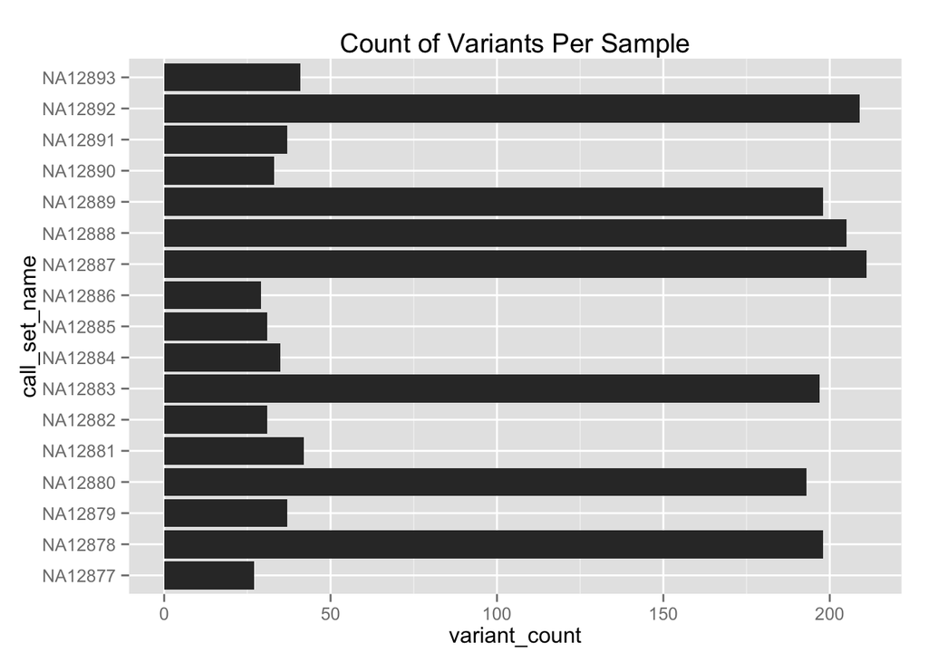

```r
ggplot(result, aes(x=call_set_name, y=variant_count)) +
  geom_bar(stat="identity") + coord_flip() +
  ggtitle("Count of Variants Per Sample")
```

and its clear to see that number of variants within BRCA1 for each sample corresponds roughly to two levels.

We can then examine the variant level data more closely:

```r
result <- DisplayAndDispatchQuery("../sql/variant-level-data-for-brca1.sql")
```

```
# Retrieve variant-level information for BRCA1 variants.
SELECT
  reference_name,
  start,
  end,
  reference_bases,
  GROUP_CONCAT(alternate_bases) WITHIN RECORD AS alternate_bases,
  quality,
  GROUP_CONCAT(filter) WITHIN RECORD AS filter,
  GROUP_CONCAT(names) WITHIN RECORD AS names,
  COUNT(call.call_set_name) WITHIN RECORD AS num_samples,
FROM
  [genomics-public-data:platinum_genomes.variants]
WHERE
  reference_name = 'chr17'
  AND start BETWEEN 41196311
  AND 41277499
HAVING
  alternate_bases IS NOT NULL
ORDER BY
  start,
  alternate_bases
```

Number of rows returned by this query: 335.

Displaying the first few rows of the dataframe of results:

| reference_name | start | end | reference_bases | alternate_bases | quality | filter | names | num_samples |
| --- | --- | --- | --- | --- | --- | --- | --- | --- |
| chr17 | 41196407 | 41196408 | G | A | 733.47 | PASS |  | 7 |
| chr17 | 41196820 | 41196822 | CT | C | 63.74 | LowQD |  | 1 |
| chr17 | 41196820 | 41196823 | CTT | C,CT | 314.59 | PASS |  | 3 |
| chr17 | 41196840 | 41196841 | G | T | 85.68 | TruthSensitivityTranche99.90to100.00,LowQD |  | 2 |
| chr17 | 41197273 | 41197274 | C | A | 1011.08 | PASS |  | 7 |
| chr17 | 41197938 | 41197939 | A | AT | 86.95 | LowQD |  | 3 |

And also work with the sample level data:

```r
result <- DisplayAndDispatchQuery("../sql/sample-level-data-for-brca1.sql")
```

```
# Retrieve sample-level information for BRCA1 variants.
SELECT
  reference_name,
  start,
  end,
  reference_bases,
  GROUP_CONCAT(alternate_bases) WITHIN RECORD AS alternate_bases,
  call.call_set_name,
  GROUP_CONCAT(STRING(call.genotype)) WITHIN call AS genotype,
  call.phaseset,
  call.genotype_likelihood,
FROM
  [genomics-public-data:platinum_genomes.variants]
WHERE
  reference_name = 'chr17'
  AND start BETWEEN 41196311
  AND 41277499
HAVING
  alternate_bases IS NOT NULL
ORDER BY
  start,
  alternate_bases,
  call.call_set_name
```

Number of rows returned by this query: 1777.

Displaying the first few rows of the dataframe of results:

| reference_name | start | end | reference_bases | alternate_bases | call_call_set_name | genotype | call_phaseset | call_genotype_likelihood |
| --- | --- | --- | --- | --- | --- | --- | --- | --- |
| chr17 | 41196407 | 41196408 | G | A | NA12878 | 0,1 |  |  |
| chr17 | 41196407 | 41196408 | G | A | NA12880 | 0,1 |  |  |
| chr17 | 41196407 | 41196408 | G | A | NA12883 | 0,1 |  |  |
| chr17 | 41196407 | 41196408 | G | A | NA12887 | 0,1 |  |  |
| chr17 | 41196407 | 41196408 | G | A | NA12888 | 0,1 |  |  |
| chr17 | 41196407 | 41196408 | G | A | NA12889 | 0,1 |  |  |